# Universidad de Costa Rica Estadística Espacial

Tarea 3

Fabián Hernández

```r
data(meuse, package="sp")
levels(meuse$ffreq) <- paste("ffreq", levels(meuse$ffreq), sep="")
levels(meuse$soil) <- paste("soil", levels(meuse$soil), sep="")
str(meuse)
```

```
  'data.frame': 155 obs. of  14 variables:
   $ x      : num  181072 181025 181165 181298 181307 ...
   $ y      : num  333611 333558 333537 333484 333330 ...
   $ cadmium: num  11.7 8.6 6.5 2.6 2.8 3 3.2 2.8 2.4 1.6 ...
   $ copper : num  85 81 68 81 48 61 31 29 37 24 ...
   $ lead   : num  299 277 199 116 117 137 132 150 133 80 ...
   $ zinc   : num  1022 1141 640 257 269 ...
   $ elev   : num  7.91 6.98 7.8 7.66 7.48 ...
   $ dist   : num  0.00136 0.01222 0.10303 0.19009 0.27709 ...
   $ om     : num  13.6 14 13 8 8.7 7.8 9.2 9.5 10.6 6.3 ...
   $ ffreq  : Factor w/ 3 levels "ffreq1","ffreq2",..: 1 1 1 1 1 1 1 1 1 1 ...
   $ soil   : Factor w/ 3 levels "soil1","soil2",..: 1 1 1 2 2 2 2 1 1 2 ...
   $ lime   : Factor w/ 2 levels "0","1": 2 2 2 1 1 1 1 1 1 1 ...
   $ landuse: Factor w/ 15 levels "Aa","Ab","Ag",..: 4 4 4 11 4 11 4 2 2 15 ...
   $ dist.m : num  50 30 150 270 380 470 240 120 240 420 ...
```

La idea con este gráfico es representar de manera visual la asociación que puede existir entre la concentración de zinc, la frecuencia de desbordamiento y el tipo de suelo de manera espacial, se usa un simbolo para representar los 6 factores de estas variable.

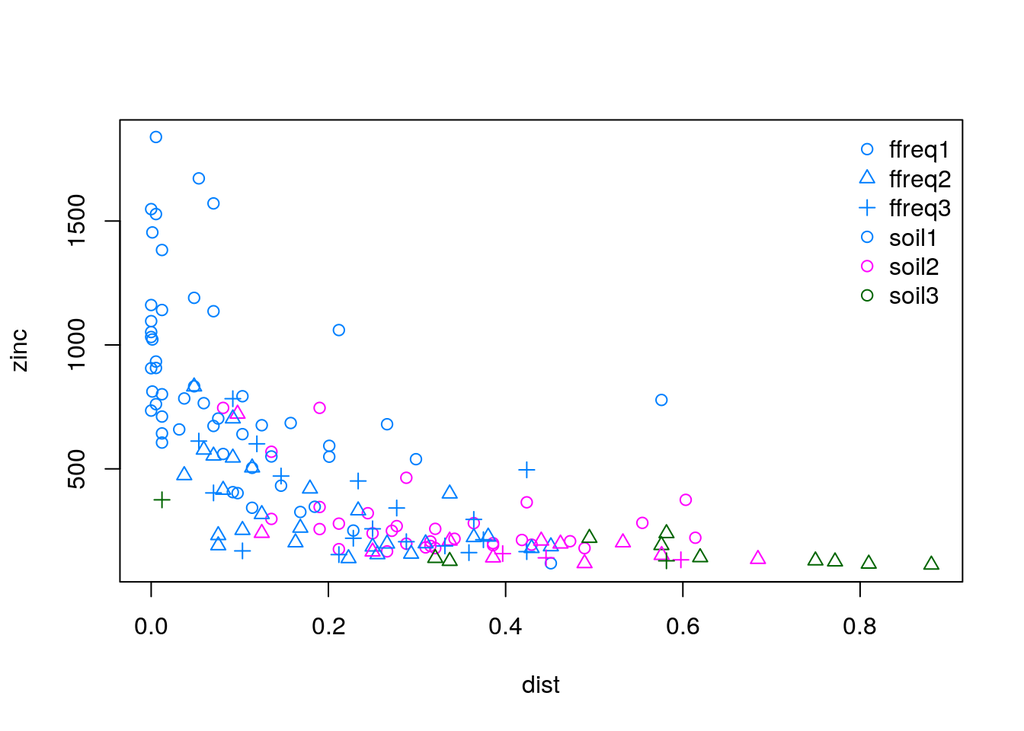

```r
palette(trellis.par.get("superpose.symbol")$col)
plot(zinc~dist, meuse, pch=as.integer(ffreq), col=soil)
legend("topright", col=c(rep(1, nlevels(meuse$ffreq)), 1:nlevels(meuse$soil)),
pch=c(1:nlevels(meuse$ffreq), rep(1, nlevels(meuse$soil))), bty="n",
legend=c(levels(meuse$ffreq), levels(meuse$soil)))
```

Esta parte es muy importante, ya que de la figura pasada se nota que la relación entre la concentración de zinc y la distancia no es lineal, entonces se hace una transformación sobre la variable zinc y la variable distancia para corregir el problema de no linealidad. Este detalle es de suma importancia si el objetivo de este estudio fuera intrepretar coeficientes, ya que estas transformaciones tendrían que tomarse en cuenta.

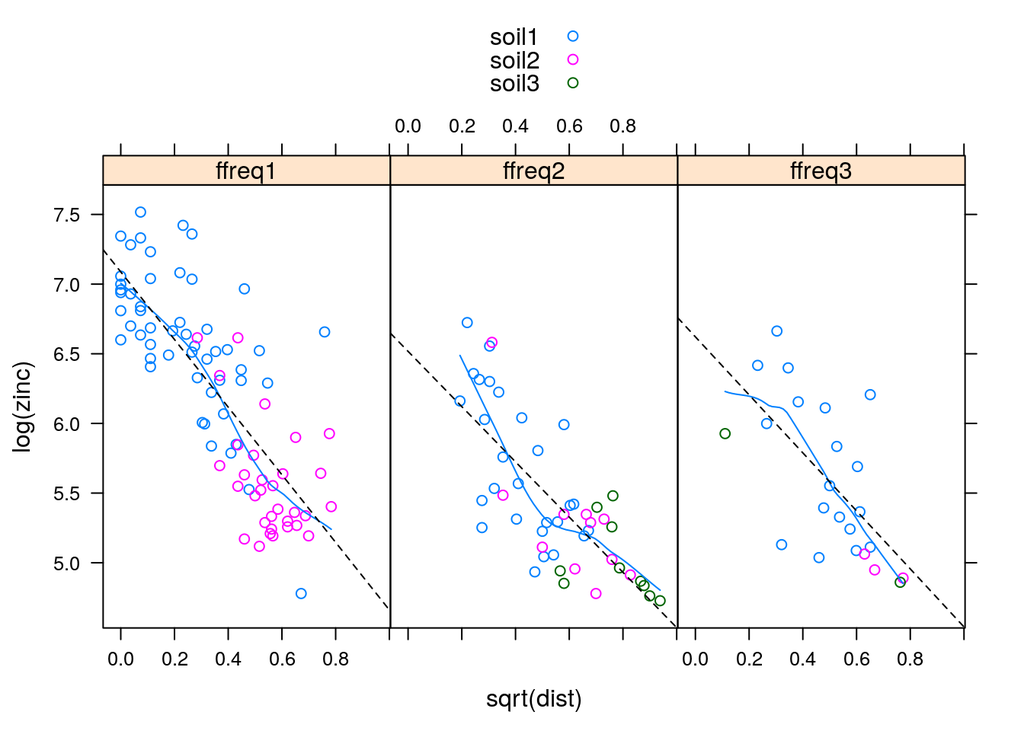

```r
xyplot(log(zinc)~sqrt(dist) | ffreq, meuse, groups=soil, panel=function(x, y, ...){
panel.xyplot(x, y, ...)
panel.loess(x, y, ...)
panel.lmline(x, y, lty="dashed", ...)
}, auto.key=TRUE)
```

Luego de hechas las transformaciones, se calcula el modelo. Es importante resaltar que todos los coeficientes dieron significativos (significancia de 5%). No se menciona porqué el autor deja por fuera la variable de tipo de suelo, sin embargo, al incluirla al modelo el coeficiente no da signficativo.

```r
r.lm <- lm(log(zinc)~sqrt(dist)+ffreq, meuse)
summary(r.lm)
```

```
  Call:
  lm(formula = log(zinc) ~ sqrt(dist) + ffreq, data = meuse)

  Residuals:
       Min       1Q   Median       3Q      Max
  -0.85595 -0.30843 -0.03045  0.29565  1.34646

  Coefficients:
              Estimate Std. Error t value Pr(>|t|)
  (Intercept)  7.02987    0.07141  98.442  < 2e-16 ***
  sqrt(dist)  -2.26602    0.15585 -14.539  < 2e-16 ***
  ffreqffreq2 -0.36054    0.07865  -4.584 9.49e-06 ***
  ffreqffreq3 -0.31667    0.09816  -3.226  0.00154 **
  ---
  Signif. codes:  0 '***' 0.001 '**' 0.01 '*' 0.05 '.' 0.1 ' ' 1

  Residual standard error: 0.4067 on 151 degrees of freedom
  Multiple R-squared:  0.6888,  Adjusted R-squared:  0.6826
  F-statistic: 111.4 on 3 and 151 DF,  p-value: < 2.2e-16
```

Además, el autor comprueba los supuestos del modelo, como si se tratase un modelo lineal estándar. Ninguno de los supuestos de la regresión lineal es violado( al menos de manera visual, los supuestos de normalidad, junto a otros supuestos no son evaluados directamente).

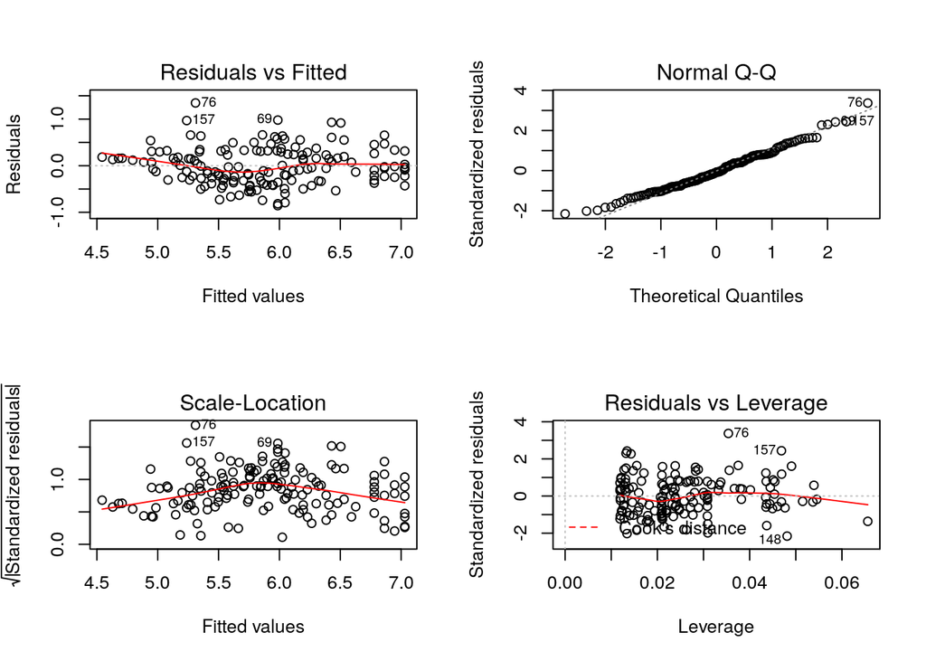

```r
op <- par(mfrow=c(2, 2)); plot(r.lm); par(op)
```

En este gráfico el autor muestra los variogramas de los residuales por cada una de las direcciones: N-S, NE-SW, E-W, SE-NW. En clase vimos un gráfico similar pero con cada uno de los variogramas como facetas. La idea con este plot, es ver si los variogramas son dependientes espacialmente.

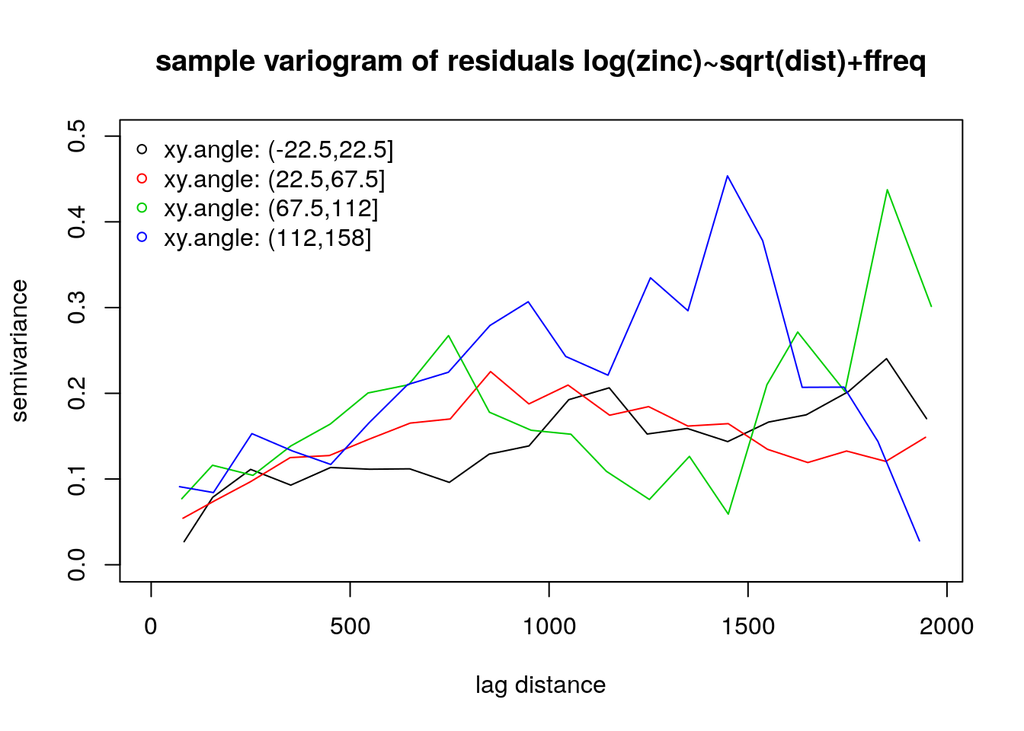

```r
plot(sample.variogram(residuals(r.lm), locations=meuse[, c("x","y")],
lag.dist.def=100, max.lag=2000, xy.angle.def=c(0, 22.5, 67.5, 112.5, 157.5, 180),
estimator="matheron"), type="l",
main="sample variogram of residuals log(zinc)~sqrt(dist)+ffreq")
```

El autor para completar el ejercicio de análisis exploratorio, muestra el mismo variograma pero sin tomar en cuenta la dirección y calcula un modelo teoríco que asemeja al variograma calculado. No se menciona en esta sección como se hizo el calculo de los parámetros, ya que por ejemplo se usa un modelo de variograma muy específico.

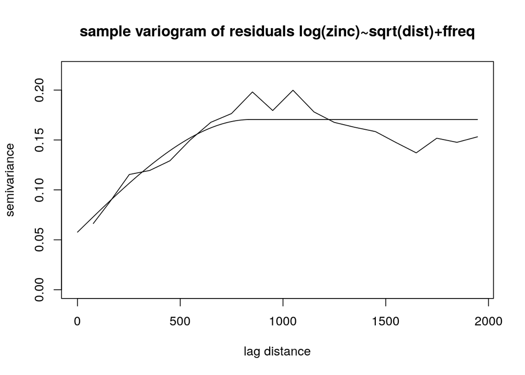

```r
plot(r.sv <- sample.variogram(residuals(r.lm), locations=meuse[, c("x","y")],
lag.dist.def=100, max.lag=2000,
estimator="matheron"), type="l",
main="sample variogram of residuals log(zinc)~sqrt(dist)+ffreq")
lines(r.sv.spher <- fit.variogram.model(r.sv, variogram.mode="RMspheric",
param=c(variance=0.1, nugget=0.05, scale=1000)))
```

```r
summary(r.sv.spher)
```

```
  Call:fit.variogram.model(sv = r.sv, variogram.model = "RMspheric",
      param = c(variance = 0.1, nugget = 0.05, scale = 1000))

  Convergence in 18 function and 42 Jacobian/gradient evaluations

  Residual Sum of Squares: 78.94483

  Residuals (epsilon):
        Min        1Q    Median        3Q       Max
  -0.033418 -0.013422 -0.003738  0.007682  0.029322

  Variogram:  RMspheric
                  Estimate     Lower   Upper
  variance         0.11283   0.10356   0.123
  snugget(fixed)   0.00000        NA      NA
  nugget           0.05769   0.04904   0.068
  scale          844.23416 767.10498 929.118
```

```r
r.georob.m0.spher.reml <- georob(log(zinc)~sqrt(dist)+ffreq, meuse, locations=~x+y,
variogram.model="RMspheric", param=c(variance=0.1, nugget=0.05, scale=1000),
tuning.psi=1000)
summary(r.georob.m0.spher.reml)
```

```
  Call:georob(formula = log(zinc) ~ sqrt(dist) + ffreq, data = meuse,
      locations = ~x + y, variogram.model = "RMspheric", param = c(variance = 0.1,
          nugget = 0.05, scale = 1000), tuning.psi = 1000)

  Tuning constant:  1000

  Convergence in 12 function and 9 Jacobian/gradient evaluations

  Estimating equations (gradient)

                                   eta         scale
    Gradient           : -6.598041e-03 -1.161658e-01

  Maximized restricted log-likelihood: -54.58371

  Predicted latent variable (B):
       Min       1Q   Median       3Q      Max
  -0.64221 -0.30197 -0.01579  0.17994  0.60994

  Residuals (epsilon):
        Min        1Q    Median        3Q       Max
  -0.627468 -0.110349 -0.001018  0.102235  0.593971

  Standardized residuals:
       Min       1Q   Median       3Q      Max
  -3.60760 -0.60304 -0.00571  0.58372  3.49971


  Gaussian REML estimates

  Variogram:  RMspheric
                  Estimate     Lower    Upper
  variance         0.13492   0.06775    0.269
  snugget(fixed)   0.00000        NA       NA
  nugget           0.05508   0.03271    0.093
  scale          876.58121 746.92121 1028.749


  Fixed effects coefficients:
              Estimate Std. Error t value Pr(>|t|)
  (Intercept)  7.08894    0.13911  50.959  < 2e-16 ***
  sqrt(dist)  -2.13186    0.25903  -8.230 8.11e-14 ***
  ffreqffreq2 -0.52682    0.06894  -7.642 2.30e-12 ***
  ffreqffreq3 -0.53828    0.10402  -5.175 7.16e-07 ***
  ---
  Signif. codes:  0 '***' 0.001 '**' 0.01 '*' 0.05 '.' 0.1 ' ' 1

  Residual standard error (sqrt(nugget)): 0.2347

  Robustness weights:
   All 155 weights are ~= 1.
```

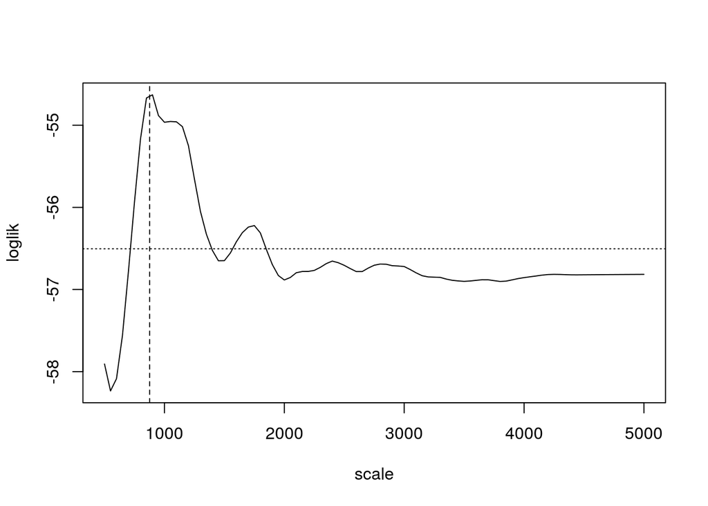

```r
r.prfl.m0.spher.reml.scale <- profilelogLik(r.georob.m0.spher.reml,
values=data.frame(scale=seq(500, 5000, by=50)))
plot(loglik~scale, r.prfl.m0.spher.reml.scale, type="l")
abline(v=coef(r.georob.m0.spher.reml, "variogram")["scale"], lty="dashed")
abline(h=r.georob.m0.spher.reml$loglik - 0.5*qchisq(0.95, 1), lty="dotted")
```

Se gráfica la varianza y el nugget en función de la escala utilizada. Esto da una visión un poco más clara de porque se usaron los parámetros de 0.05 el nugget y 0.1 la varianza.

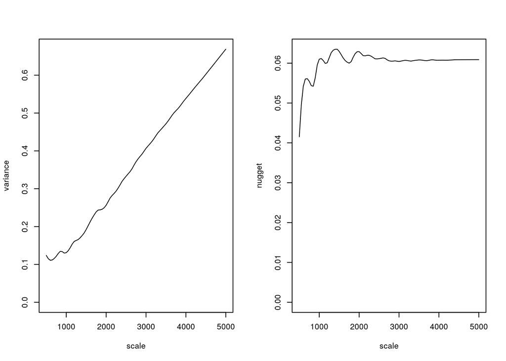

```r
op <- par(mfrow=c(1,2), cex=0.66)
plot(variance~scale, r.prfl.m0.spher.reml.scale, ylim=c(0, max(variance)), type="l")
plot(nugget~scale, r.prfl.m0.spher.reml.scale, ylim=c(0, max(nugget)), type="l")
```

```r
par(op)
```

```r
waldtest(r.georob.m0.spher.reml, .~.-ffreq)
```

```
  Wald test

  Model 1: log(zinc) ~ sqrt(dist) + ffreq
  Model 2: log(zinc) ~ sqrt(dist)
    Res.Df Df      F    Pr(>F)
  1    151
  2    153 -2 31.181 4.616e-12 ***
  ---
  Signif. codes:  0 '***' 0.001 '**' 0.01 '*' 0.05 '.' 0.1 ' ' 1
```

También el autor usa la función glht del paquete multcomp para comparar al mismo tiempo todos los parámetros del modelo lineal.

```r
summary(glht(r.georob.m0.spher.reml,
linfct = mcp(ffreq = c("ffreq1 - ffreq2 = 0", "ffreq1 - ffreq3 = 0",
"ffreq2 - ffreq3 = 0"))))
```

```
     Simultaneous Tests for General Linear Hypotheses

  Multiple Comparisons of Means: User-defined Contrasts


  Fit: georob(formula = log(zinc) ~ sqrt(dist) + ffreq, data = meuse,
      locations = ~x + y, variogram.model = "RMspheric", param = c(variance = 0.1,
          nugget = 0.05, scale = 1000), tuning.psi = 1000)

  Linear Hypotheses:
                       Estimate Std. Error z value Pr(>|z|)
  ffreq1 - ffreq2 == 0  0.52682    0.06894   7.642   <1e-06 ***
  ffreq1 - ffreq3 == 0  0.53828    0.10402   5.175   <1e-06 ***
  ffreq2 - ffreq3 == 0  0.01146    0.09597   0.119    0.992
  ---
  Signif. codes:  0 '***' 0.001 '**' 0.01 '*' 0.05 '.' 0.1 ' ' 1
  (Adjusted p values reported -- single-step method)
```

También se verifica que la interacción entre la distancia y la frecuencia no mejora el modelo, también usando la prueba de Wald para modelos anidados.

```r
waldtest(r.georob.m0.spher.reml, .~.+sqrt(dist):ffreq)
```

```
  Wald test

  Model 1: log(zinc) ~ sqrt(dist) + ffreq
  Model 2: log(zinc) ~ sqrt(dist) + ffreq + sqrt(dist):ffreq
    Res.Df Df      F Pr(>F)
  1    151
  2    149  2 0.6754 0.5105
```

El mismo resultado de no significancia se obtiene para el tipo de suelo.

```r
 waldtest(r.georob.m0.spher.reml, .~.+soil)
```

```
  Wald test

  Model 1: log(zinc) ~ sqrt(dist) + ffreq
  Model 2: log(zinc) ~ sqrt(dist) + ffreq + soil
    Res.Df Df      F Pr(>F)
  1    151
  2    149  2 2.2681 0.1071
```

Se usa la función de step(step-wise) para seleccionar el mejor modelo según el criterio del AIC, obteniendose los mismos resultados anteriores en cuanto a significancia de los coeficientes.

```r
step(r.georob.m0.spher.reml, scope=log(zinc)~ffreq*sqrt(dist)+soil)
```

```
  Start:  AIC=106.91
  log(zinc) ~ sqrt(dist) + ffreq

                     Df    AIC Converged
  <none>                106.91
  + soil              2 107.20         1
  + ffreq:sqrt(dist)  2 109.72         1
  - ffreq             2 166.39         1
  - sqrt(dist)        1 178.01         1
```

```
  Tuning constant:  1000

  Fixed effects coefficients:
  (Intercept)   sqrt(dist)  ffreqffreq2  ffreqffreq3
       7.0938      -2.1459      -0.5263      -0.5368

  Variogram:  RMspheric
   variance(fixed)    snugget(fixed)     nugget(fixed)      scale(fixed)
           0.12299           0.00000           0.05597         872.39971
```

Se ejecuta el mismo procedimiento de selección de modelos pero haciendo la restimación de los parámetros para cada modelo evaluado (lo cúal lo hace más lento.)

```r
step(r.georob.m0.spher.reml, scope=log(zinc)~ffreq*sqrt(dist)+soil,fixed.add1.drop1=FALSE)
```

```
  Start:  AIC=112.91
  log(zinc) ~ sqrt(dist) + ffreq

                     Df    AIC Converged
  <none>                112.91         1
  + soil              2 113.11         1
  + ffreq:sqrt(dist)  2 115.63         1
  - sqrt(dist)        1 144.28         1
  - ffreq             2 158.21         1
```

```
  Tuning constant:  1000

  Fixed effects coefficients:
  (Intercept)   sqrt(dist)  ffreqffreq2  ffreqffreq3
       7.0938      -2.1459      -0.5263      -0.5368

  Variogram:  RMspheric
          variance    snugget(fixed)            nugget             scale
           0.12299           0.00000           0.05597         872.39971
```

Se vuelve a calcular el modelo pero otra vez usando el método de máxima verosimilitud.

```r
r.georob.m0.spher.ml <- update(r.georob.m0.spher.reml, control=control.georob(ml.method="ML"))
```

Se nota que aunque son los mismo modelos, los métodos de estimación hace que la estimación del AIC sea diferente.

```r
extractAIC(r.georob.m0.spher.reml, REML=TRUE)
```

```
  [1]   7.0000 123.1674
```

```r
extractAIC(r.georob.m0.spher.ml)
```

```
  [1]   7.0000 112.9091
```

También, se usa validación cruzada para realizar la comparación de los modelos, obteniendose medidas de comparación de errores como: me, mede, rmse, made, qne, msse, medsse.

```r
r.cv.m0.spher.reml <- cv(r.georob.m0.spher.reml, seed=3245, lgn=TRUE)
r.georob.m1.spher.reml <- update(r.georob.m0.spher.reml, .~.-ffreq)
r.cv.m1.spher.reml <- cv(r.georob.m1.spher.reml, seed=3245, lgn=TRUE)
summary(r.cv.m0.spher.reml)
```

```
  Statistics of cross-validation prediction errors
         me       mede       rmse       made        qne       msse
  -0.009512  -0.035082   0.372749   0.357945   0.360882   0.972375
     medsse       crps
   0.379926   0.208286

  Statistics of back-transformed cross-validation prediction errors
        me      mede      rmse      made       qne      msse    medsse
  -18.4060  -33.7740  196.9399  144.0156  143.7456    1.0639    0.3068
```

```r
summary(r.cv.m1.spher.reml)
```

```
  Statistics of cross-validation prediction errors
       me     mede     rmse     made      qne     msse   medsse     crps
  0.04183  0.03423  0.43470  0.40486  0.40773  1.03625  0.41027  0.23985

  Statistics of back-transformed cross-validation prediction errors
        me      mede      rmse      made       qne      msse    medsse
   14.3101  -22.8901  220.8882  142.4411  147.1828    1.6038    0.3179
```

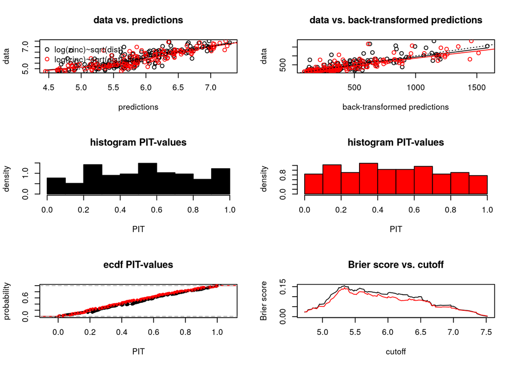

```r
op <- par(mfrow=c(3,2))
plot(r.cv.m1.spher.reml, "sc")
plot(r.cv.m0.spher.reml, "sc", add=TRUE, col=2)
abline(0, 1, lty="dotted")
legend("topleft", pch=1, col=1:2, bty="n",
legend=c("log(zinc)~sqrt(dist)", "log(zinc)~sqrt(dist)+ffreq"))
plot(r.cv.m1.spher.reml, "lgn.sc"); plot(r.cv.m0.spher.reml, "lgn.sc", add=TRUE, col=2)
abline(0, 1, lty="dotted")
plot(r.cv.m1.spher.reml, "hist.pit")
plot(r.cv.m0.spher.reml, "hist.pit", col=2)
plot(r.cv.m1.spher.reml, "ecdf.pit")
plot(r.cv.m0.spher.reml, "ecdf.pit", add=TRUE, col=2)
abline(0, 1, lty="dotted")
plot(r.cv.m1.spher.reml, "bs")
plot(r.cv.m0.spher.reml, add=TRUE, "bs", col=2)
```

```r
par(op)
```

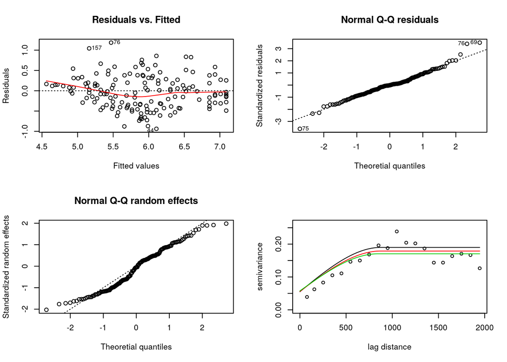

```r
op <- par(mfrow=c(2,2), cex=0.66)
plot(r.georob.m0.spher.reml, "ta"); abline(h=0, lty="dotted")
plot(r.georob.m0.spher.reml, "qq.res"); abline(0, 1, lty="dotted")
plot(r.georob.m0.spher.reml, "qq.ranef"); abline(0, 1, lty="dotted")
plot(r.georob.m0.spher.reml, lag.dist.def=100, max.lag=2000)
lines(r.georob.m0.spher.ml, col=2); lines(r.sv.spher, col=3)
```

```r
par(op)
```